# assignment03

Weijia Hu

2020/10/14

```r
library(httr)
library(xml2)
library(stringr)
library(knitr)
```

# APIs

- Using the NCBI API, look for papers that show up under the term “sars-cov-2 trial vaccine.” Look for the data in the pubmed database, and then retrieve the details of the paper as shown in lab 7. How many papers were you able to find?

```r
# Downloading the website
website <- xml2::read_html("https://pubmed.ncbi.nlm.nih.gov/?term=sars-cov-2+trial+vaccine")
# Finding the counts
counts <- xml2::xml_find_first(website, "/html/body/main/div[9]/div[2]/div[2]/div[1]/span")
# Turning it into text
counts <- as.character(counts)
# Extracting the data using regex
stringr::str_extract(counts, "[0-9,]+")
```

```
## [1] "560"
```

```r
query_ids <- GET(
  url   = "https://eutils.ncbi.nlm.nih.gov/entrez/eutils/esearch.fcgi",
  query = list(
    db ="pubmed",
    term= "sars-cov-2 trial vaccine",
    retmax=  250
  )
)
# Extracting the content of the response of GET
ids <- httr::content(query_ids)
```

- As we did in lab 7. Create a dataset. ### Pubmed ID number

```r
# Turn the result into a character vector
ids <- as.character(ids)
# Find all the ids
ids <- stringr::str_extract_all(ids, "<Id>[0-9]+</Id>")[[1]]
# Remove all the leading and trailing <Id> </Id>. Make use of "|"
ids <- stringr::str_remove_all(ids, "<Id>|</Id>")
```

```r
publications <- GET(
  url   = "https://eutils.ncbi.nlm.nih.gov/entrez/eutils/efetch.fcgi",
  query = list(
    db= "pubmed",
    id = paste(ids, collapse = ","),
    retmax = 250,
    rettype = "abstract"
    )
)
# Turning the output into character vector
publications <- httr::content(publications)
publications_txt <- as.character(publications)
```

```r
pub_char_list <- xml2::xml_children(publications)
pub_char_list <- sapply(pub_char_list, as.character)
```

### Abstract of the paper

```r
abstracts <- str_extract(pub_char_list, "<Abstract>(\\n|.)+</Abstract>")
abstracts <- str_remove_all(abstracts, "</?[[:alnum:]]+>")
abstracts <- str_replace_all(abstracts, "\\s+", " ")
```

### Title of the paper

```r
titles <- str_extract(pub_char_list, "<ArticleTitle>(\\n|.)+</ArticleTitle>")
titles <- str_remove_all(titles, "</?[[:alnum:]]+>")
titles <- str_replace_all(titles, "\\s+", " ")
```

### Name of the journal where it was published

```r
journals <- str_extract(pub_char_list, "<Title>(\\n|.)+</Title>")
journals <- str_remove_all(journals, "</?[[:alnum:]]+>")
journals <- str_replace_all(journals, "\\s+", " ")
```

### Publication date

```r
dates <- str_extract_all(pub_char_list, "<PubDate>(\\n|.)+</PubDate>")
dates <- str_remove_all(dates, "</?[[:alnum:]]+>")
dates <- str_replace_all(dates, "\\s+", " ")
```

```r
database <- data.frame(
  PubMedID = ids,
  Title = titles,
  Journal=journals,
  PublicationDate=dates,
  Abstract = abstracts
)
knitr::kable(database)
```

| PubMedID | Title | Journal | PublicationDate | Abstract |
| --- | --- | --- | --- | --- |
| 33043110 | EXPLORING SURFACE GLYCOPROTEIN TO DESIGN MULTI-EPITOPE VACCINE AGAINST COVID-19. | Informatics in medicine unlocked | 2020 Oct 04 | Stimulation and generation of T and B cell mediated long-term immune response is essential for the curbing of a deadly virus such as SAR-CoV-2. Immunoinformatics approach in vaccine design takes advan… |
| 33042591 | Impact of COVID-19 on clinical trials and clinical research: A systematic review. | Nepal journal of epidemiology | 2020 Sep | Background: The World Health Organization has reported more than 31,186,000 confirmed cases of coronavirus disease-19 (COVID-19), including 962,343 deaths, worldwide as on September 21, 2020. The curr… |
| 33038433 | COVID-19: discovery, diagnostics and drug development. | Journal of hepatology | 2020 Oct 07 | An epidemic of acute respiratory syndrome (Covid-19) started in humans in Wuhan in 2019, and became a pandemic. Groups from China Identified and sequenced the virus responsible for COVID-19, named SAR… |
| 33022293 | Clinical trial protocols of repurposed prophylaxis for COVID-19: a review. | Medecine et maladies infectieuses | 2020 Oct 03 | Efficient therapeutic strategies are needed to counter the COVID-19 pandemic, caused by the SARS-CoV-2 virus. In a context where specific vaccines are not yet available, the containment of the pandemi… |
| 33013255 | Screening of FDA Approved Drugs Against SARS-CoV-2 Main Protease: Coronavirus Disease. | International journal of peptide research and therapeutics | 2020 Sep 28 | At the end of December 2019, a new strain of coronavirus was identified in the Wuhan city of Hubei province in China. Within a shorter period of time, an unprecedented outbreak of this strain was witn… |
| 33012348 | SARS-CoV-2 Vaccine Development: Current Status. | Mayo Clinic proceedings | 2020 10 | In the midst of the severe acute respiratory syndrome coronavirus 2 pandemic and its attendant morbidity and mortality, safe and efficacious vaccines are needed that induce protective and long-lived i… |
| 32998488 | Status of COVID-19 vaccine development. | Tidsskrift for den Norske laegeforening : tidsskrift for praktisk medicin, ny raekke | 2020 09 29 | NA |
| 32998157 | COVID-19 vaccine BNT162b1 elicits human antibody and TH1 T-cell responses. | Nature | 2020 Sep 30 | An effective vaccine is needed to halt the spread of the severe acute respiratory syndrome coronavirus-2 (SARS-CoV-2) pandemic. Recently, we reported safety, tolerability and antibody response data fr… |
| 32997699 | Analysis of COVID-19 clinical trials: A data-driven, ontology-based, and natural language processing approach. | PloS one | 2020 | With the novel COVID-19 pandemic disrupting and threatening the lives of millions, researchers and clinicians have been recently conducting clinical trials at an unprecedented rate to learn more about… |
| 32994572 | COVID vaccine confidence requires radical transparency. | Nature | 2020 10 | NA |
| 32991794 | Safety and Immunogenicity of SARS-CoV-2 mRNA-1273 Vaccine in Older Adults. | The New England journal of medicine | 2020 Sep 29 | Testing of vaccine candidates to prevent infection with severe acute respiratory syndrome coronavirus 2 (SARS-CoV-2) in an older population is important, since increased incidences of illness and deat… |
| 32988688 | Intention to participate in a COVID-19 vaccine clinical trial and to get vaccinated against COVID-19 in France during the pandemic. | Vaccine | 2020 10 21 | The world is facing the COVID-19 pandemic. The development of a vaccine is challenging. We aimed to determine the proportion of people who intend to get vaccinated against COVID-19 in France or to par… |
| 32985963 | Coronavirus Disease 2019 Vaccine Development: An Overview. | Viral immunology | 2020 Sep 23 | To this day, the coronavirus disease 2019 (COVID-19) pandemic has not shown signs of abating. Moreover, the virus responsible for the pandemic, severe acute respiratory syndrome coronavirus 2, has evo… |
| 32978611 | COVID-vaccine results are on the way - and scientists’ concerns are growing. | Nature | 2020 10 | NA |
| 32974268 | Overview of the First 6 Months of Clinical Trials for COVID-19 Pharmacotherapy: The Most Studied Drugs. | Frontiers in public health | 2020 | SARS-CoV-2 rapidly spread from China until it was defined a pandemic by WHO in March 2020. Related scientific papers have rapidly extended information regarding the diagnosis, treatment and epidemiolo… |
| 32973779 | The 2020 Pandemic: Current SARS-CoV-2 Vaccine Development. | Frontiers in immunology | 2020 | Coronaviruses are enveloped viruses with a positive-sense single-stranded RNA genome infecting animals and humans. Coronaviruses have been described more than 70 years ago and contain many species. Se… |
| 32969973 | Coronavirus disease-19 vaccine development utilizing promising technology. | Current opinion in HIV and AIDS | 2020 11 | Coronavirus disease-19 (COVID-19) is a highly transmittable and pathogenic pneumonia-causing disease, which is caused by severe acute respiratory syndrome coronavirus-2, resulting in millions of death… |
| 32969369 | Safety and Efficacy of Different Therapeutic Interventions on Prevention and Treatment of COVID-19. | Journal of Nepal Health Research Council | 2020 Sep 07 | Severe acute respiratory syndrome coronavirus 2 (SARS-CoV-2) is the strain of coronavirus that causes coronavirus disease 2019 (COVID-19), a respiratory illness. COVID-19 has now become a global publi… |
| 32967006 | SARS-CoV-2 vaccines in development. | Nature | 2020 Sep 23 | Severe acute respiratory syndrome coronavirus 2 (SARS-CoV-2) was first reported in late 2019 in China and is the causative agent of the coronavirus disease 2019 (COVID-19) pandemic. To mitigate the ef… |
| 32963672 | Expedited COVID-19 vaccine trials: a rat-race with challenges and ethical issues. | The Pan African medical journal | 2020 | The intense global efforts are directed towards development of vaccines to halt the COVID-19 virus pandemic. There are 160 candidate vaccines under clinical trials across the world using different mol… |
| 32958009 | The use of mesenchymal stromal cells in the treatment of coronavirus disease 2019. | Journal of translational medicine | 2020 09 21 | More than seven months into the coronavirus disease -19 (COVID-19) pandemic, infection from the severe acute respiratory syndrome coronavirus-2 (SARS-CoV-2) has led to over 21.2 million cases and resu… |
| 32943115 | Using BCG vaccine to enhance non-specific protection of health care workers during the COVID-19 pandemic: A structured summary of a study protocol for a randomised controlled trial in Denmark. | Trials | 2020 Sep 17 | The Bacille Calmette-Guérin (BCG) vaccine against tuberculosis is associated with non- specific protective effects against other infections, and significant reductions in all-cause morbidity and morta… |
| 32934758 | Tuberculosis and COVID-19: Lessons from the Past Viral Outbreaks and Possible Future Outcomes. | Canadian respiratory journal | 2020 | The threat of contagious infectious diseases is constantly evolving as demographic explosion, travel globalization, and changes in human lifestyle increase the risk of spreading pathogens, leading to … |
| 32934375 | Researchers highlight ‘questionable’ data in Russian coronavirus vaccine trial results. | Nature | 2020 09 | NA |
| 32933536 | Pathophysiology and treatment strategies for COVID-19. | Journal of translational medicine | 2020 09 15 | The outbreak of Coronavirus disease of 2019 (COVID-19) caused by the Severe Acute Respiratory Syndrome coronavirus 2 (SARS-CoV-2), has posed a serious health threat. The increasing number of COVID-19 … |
| 32929259 | Scientists relieved as coronavirus vaccine trial restarts - but question lack of transparency. | Nature | 2020 09 | NA |
| 32918548 | Multicenter interim guidance on use of antivirals for children with COVID-19/SARS-CoV-2. | Journal of the Pediatric Infectious Diseases Society | 2020 Sep 12 | Although Coronavirus Disease 2019 (COVID-19) is a mild infection in most children, a small proportion develop severe or critical illness. Data evaluating agents with potential antiviral activity conti… |
| 32918053 | China’s coronavirus vaccine shows military’s growing role in medical research. | Nature | 2020 09 | NA |
| 32908297 | The underdog coronavirus vaccines that the world will need if front runners stumble. | Nature | 2020 09 | NA |
| 32908295 | A leading coronavirus vaccine trial is on hold: scientists react. | Nature | 2020 Sep 09 | NA |

[output cut: 197 more lines]

# Text Mining

```r
library(readr)
library(dplyr)
```

```r
library(tidytext)
library(ggplot2)
```

```r
txt_m <- read_csv("https://raw.githubusercontent.com/USCbiostats/data-science-data/master/03_pubmed/pubmed.csv")
```

## 1.Tokenize the abstracts and count the number of each token. Do you see anything interesting? Does removing stop words change what tokens appear as the most frequent? What are the 5 most common tokens for each search term after removing stopwords?

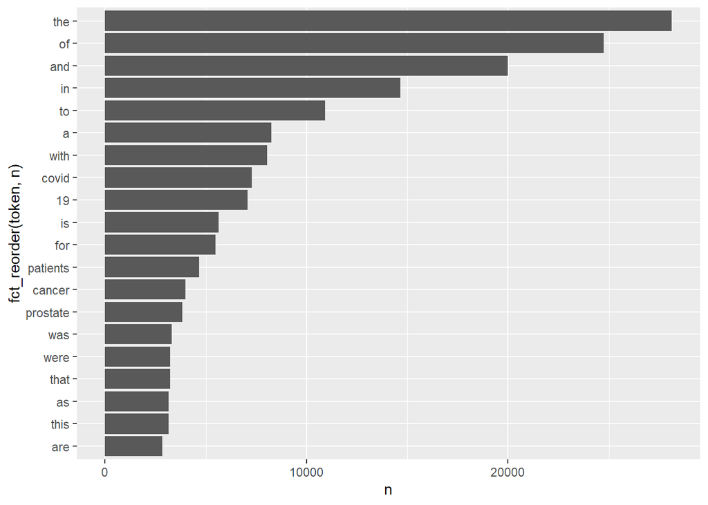

```r
library(forcats)
txt_m %>%
  unnest_tokens(output =  token, input = abstract) %>%
  count(token, sort=T)%>%
  top_n(n=20, wt=n)%>%
  ggplot(aes(x=n, y=fct_reorder(token,n)))+
  geom_col()
```

- The top 7 words are stop words. So, let’s remove the stop words.

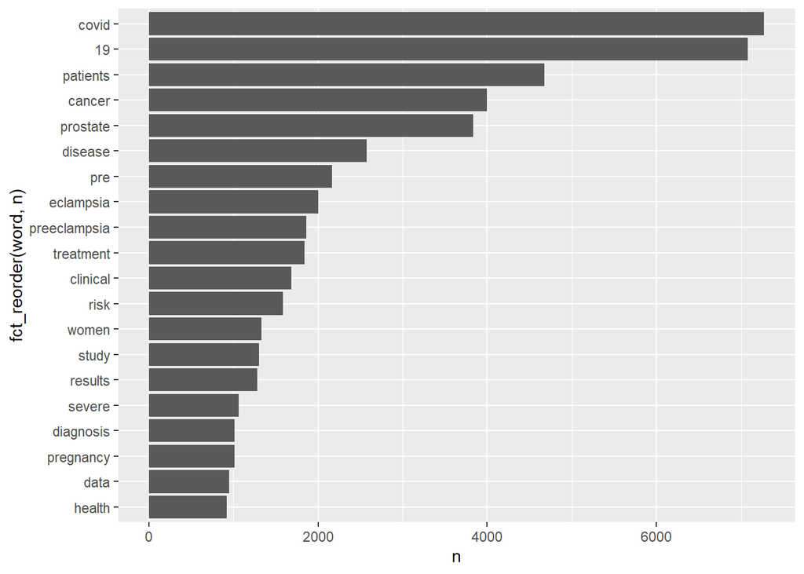

```r
txt_m %>%
  unnest_tokens(word, abstract)%>%
  anti_join(tidytext::stop_words)%>%
  count(word, sort=T)%>%
  top_n(20,n)%>%
  ggplot(aes(x=n, y=fct_reorder(word, n)))+
  geom_col()
```

```r
txt_m %>%
  unnest_tokens(word, abstract)%>%
  anti_join(tidytext::stop_words)%>%
  group_by(term)%>%
  count(word)%>%
  top_n(5,n)
```

```
## # A tibble: 25 x 3
## # Groups:   term [5]
##    term            word         n
##    <chr>           <chr>    <int>
##  1 covid           19        7035
##  2 covid           covid     7275
##  3 covid           disease    943
##  4 covid           pandemic   800
##  5 covid           patients  2293
##  6 cystic fibrosis cf         625
##  7 cystic fibrosis cystic     862
##  8 cystic fibrosis disease    400
##  9 cystic fibrosis fibrosis   867
## 10 cystic fibrosis patients   586
## # ... with 15 more rows
```

- The 5 most common tokens for each search term after removing stop words are shown.

## 2. Tokenize the abstracts into bigrams. Find the 10 most common bigram and visualize them with ggplot2.

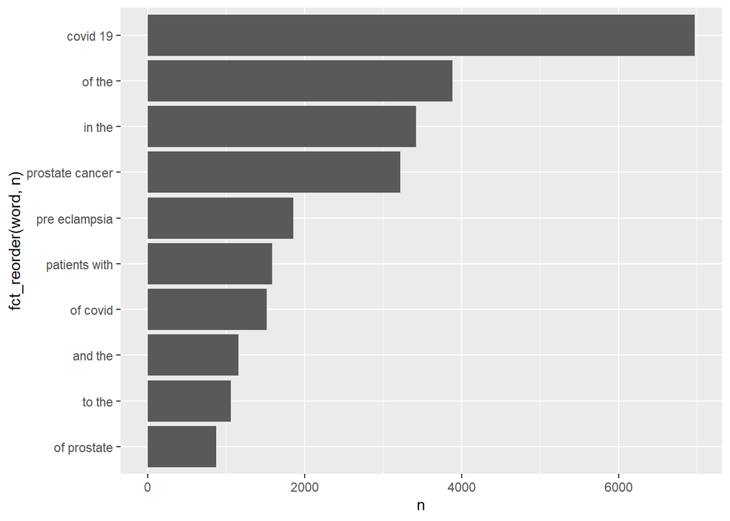

```r
txt_m %>%
 unnest_ngrams(word, abstract, n = 2) %>%
 count(word, sort = TRUE)%>%
 top_n(10,n)%>%
 ggplot(aes(x=n, y=fct_reorder(word, n)))+
 geom_col()
```

- I noticed that the second and third words are all stop words. So, let’s remove the stop words again.

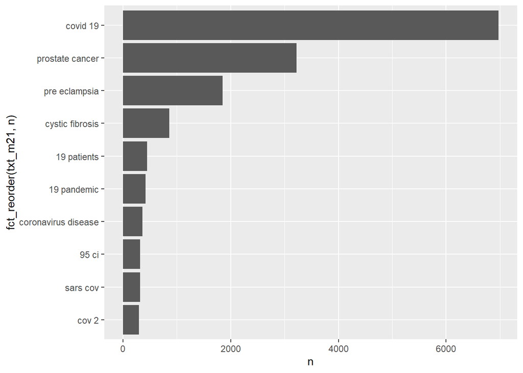

```r
library(tidyr)
txt_m2 <- txt_m %>%
  unnest_ngrams(output=word, input=abstract ,n=2)%>%
  separate (col = word, into = c("word1", "word2"),sep = " ")%>%
  anti_join(
    tidytext::stop_words, by =c("word1" = "word")
  ) %>%
  anti_join(
    tidytext::stop_words, by =c("word2" = "word")
  ) %>%

  unite(txt_m21, word1, word2, sep= " ")

txt_m2 %>%
  count(txt_m21, sort = TRUE)%>%
 top_n(10,n)%>%
 ggplot(aes(x=n, y=fct_reorder(txt_m21, n)))+
 geom_col()
```

- After removing the stop words, The “covid 19” is the top 1 bigram.

## 3. Calculate the TF-IDF value for each word-search term combination. (here you want the search term to be the “document”) What are the 5 tokens from each search term with the highest TF-IDF value? How are the results different from the answers you got in question 1?

```r
txt_m1 <- txt_m %>%
  unnest_tokens(abstract, abstract) %>%
  filter(!(abstract %in% stop_words$word)) %>%
  count(abstract, term) %>%
  group_by(term)%>%
  bind_tf_idf(abstract, term, n) %>%
  top_n(5, n) %>%
  arrange(desc(tf_idf))

txt_m1 %>%
    group_by(term)%>%
arrange(desc(tf_idf))
```

```
## # A tibble: 25 x 6
## # Groups:   term [5]
##    abstract     term                n      tf   idf tf_idf
##    <chr>        <chr>           <int>   <dbl> <dbl>  <dbl>
##  1 covid        covid            7275 0.0647  1.61  0.104
##  2 prostate     prostate cancer  3832 0.0563  1.61  0.0906
##  3 eclampsia    preeclampsia     2005 0.0255  1.61  0.0411
##  4 preeclampsia preeclampsia     1863 0.0237  1.61  0.0382
##  5 meningitis   meningitis        429 0.0164  1.61  0.0264
##  6 cf           cystic fibrosis   625 0.0234  0.916 0.0215
##  7 fibrosis     cystic fibrosis   867 0.0325  0.511 0.0166
##  8 cystic       cystic fibrosis   862 0.0323  0.511 0.0165
##  9 meningeal    meningitis        219 0.00837 1.61  0.0135
## 10 pandemic     covid             800 0.00711 1.61  0.0114
## # ... with 15 more rows
```

- The top 5 tokens for term “Covid”: covid, pandemic, 19, disease and patients.
- The top 5 tokens for term “prostate cancer”: prostate, cancer, disease, patients and treatment.
- The top 5 tokens for term “preeclampsia”: eclampsia, preeclampsia, pregnancy, pre and treatment.
- The top 5 tokens for term “meningitis”: meningitis, meningeal, csf, clinical and patients.
- The top 5 tokens for term “cystic fibrosis”: cf, fibrosis, cystic, disease and patients.